# 基于大数据的微博评论情感分类

2019/5/30

## 研究背景

## 微博

- 社交主流平台
- 海量数据
- 评论长度小
- 信息多样

## 微博

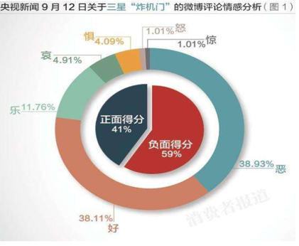

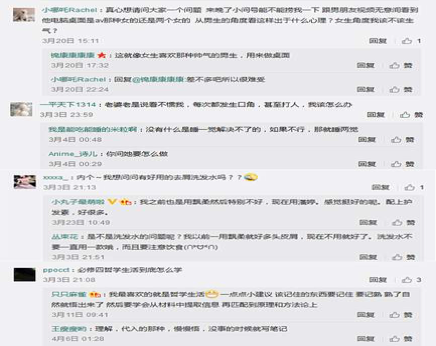

## 现状

- 热衷英文情感分类
- 中文微博情感分类模型匮乏

## 数据展示

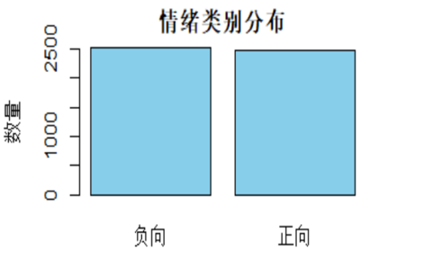

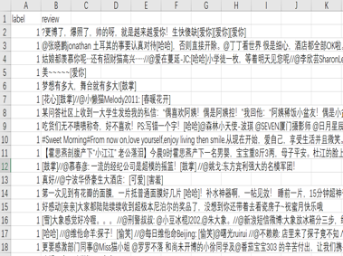

每一个文本都是由一个标记和一段微博评论构成的，这样的数据集是不能进行分类的,因此需要对上述数据进行**数据预处理**。

## 词云

## 直观展示

- 运用wordcloud包
- 运用wordcloud2包

## 美观需求

- 用户体验对比显而易见

[figure not shown]

最终选择wordcloud2中的默认图形“circle”作为了最终展示形式，并且确定参数**size=2.6**时最为美观。

## 结果分析

### 正面情感

“嘻嘻”“鼓掌”两个词语出现的频率都在1000以上，远远高出其他，而且这两个词语在我们的认知中也的确非常符合正面情感的表达，而之后的“偷笑”“开心”等词，也都是表达正面情感的词语。

### 负面情感

而在负面情感词云中，“抓狂”出现的频率一骑绝尘，甚至超过了2-5名的总和，这是我们未曾预料到的。在2-10名中也出现“嘻嘻”这个词语也令我们颇感意外。

## 结果分析

### 意义挖掘

经过我们的初步分析，我们认为负面词云中“嘻嘻”的出现与微博中“[嘻嘻]”这个表情**频繁地反讽**使用有关，同样，“抓狂”“鼓掌”“偷笑”等词语的出现频率也受到了微博表情的影响。

值得一提的是，“北京”和“中国”这两个中性名词在正负词云中的出现频数都挺进了前十，这说明我国微博用户甚至网民关心国家大事、常常将**个人情感系于家国要事**的特点。

绘制词云本身并不复杂，我们的精力更多集中在了如何绘制**美观、直观、**可以明确反映**数据集特点**的词云。我们绘制的词云，结果基本符合我们的预期。但是词云的具体呈现显然受到了微博表情功能的影响，这是我们仍需改进的方向。

## 数据预处理

## 文本分词

- jiebaR程序包
- worker（）函数进行文本分词

```
  'wk <- jiebaR::worker()
  jiebaR::new_user_word(wk, "咚咚锵", "n")
  seg_word <- wk[raw_doc]
```

- 去除数字、英文字母、单个字、专业词汇

### 创新之处

- 一万行文本处理效率低
- “咚咚锵”从未出现
- 所有评论相连为一个大字符串
- 只对一个字符串分词

## 格式转换

- 转换为词向量
- 载入tm包
- VectorSource函数、Corpus函数以及DocumentTermMatrix函数生成词矩阵
- 出现次数>25的频繁词向量作为最终分类变量
- 稀疏矩阵转化为data.frame迎合分类函数

## 流程概述

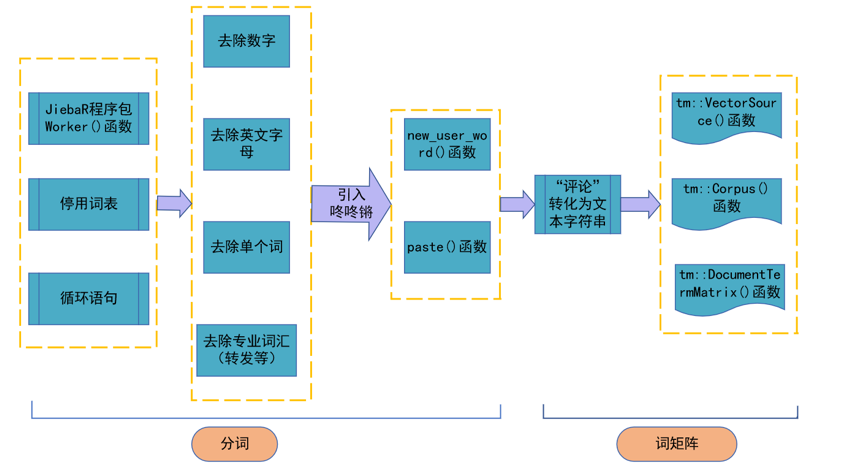

## 算法介绍

## 随机森林

对数据集中的列变量以及行观测进行随机化，会生成不同的分类树，这些树都是独立同分布的决策树，这些决策树是没有经过剪枝，也就是处于过拟合的状态，每一棵树都依赖一个随机向量，最后进行汇总，即构成森林。

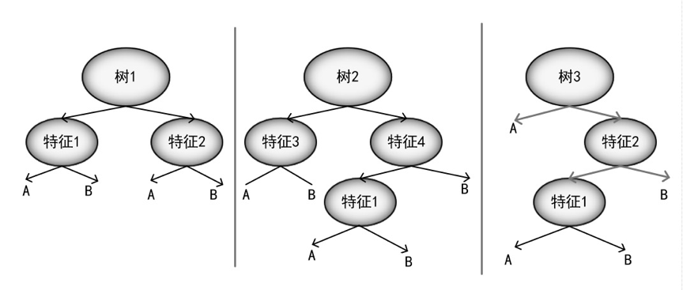

## Svm

寻找一个超平面作为分类决策面实现对正例和反例的分割,并尽量使两个类别之间的空白间隔最大,以保证分类的高可信度。支持向量机在解决小样本、非线性以及高维模式识别中有许多独特的优势。

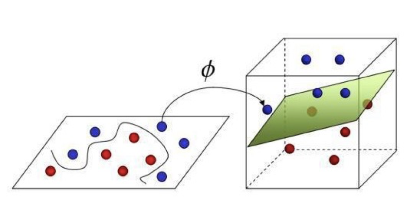

## Xgb

通过一系列弱分类器的迭代计算实现准确的分类效果，就是不断地添加树，不断地进行特征分裂来生长一棵树，每次添加一个树，就是学习一个新函数，去拟合上次预测的残差。当训练完成得到k棵树，要预测一个样本的分数，就是根据这个样本的特征，在每棵树中会落到对应的一个叶子节点，每个叶子节点就对应一个分数，最后只需要将每棵树对应的分数加起来就是该样本的预测值。

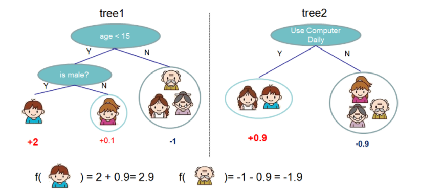

## 朴素贝叶斯

把自己求出的分类在训练数据集中先分好，然后计算在不同分类中各个属性的属性值或范围对应的概率相当于P（B|A），然后根据属性分类概率P（B），所求分类概率P（A），判断已知属性的样本的分类。

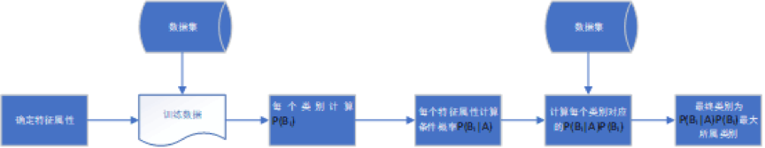

## 建模过程

## 随机森林分类模型

- 运用随机森林的默认参数进行训练
- randomForest程序包的randomForest方法

```
set.seed(1)#设置随机数种子
#调用randomFprest模型
#这个一个小技巧，当存在很多变量时用y~.来表示，"."代表x
rf_model <-
  randomForest::randomForest(
    y ~ .,
    train_final_df,#表示数据集，在这里要使用数据框的形式导入数据
    proximity = TRUE,#显示行之间的相似度，这样也可以获取袋外误差
    importance = TRUE,#显示变量的重要性顺利
    ntree = 500,#500个树
  )
```

## 随机森林分类模型

- 找到最佳的决策树个数以及变量个数
- 两个for循环语句进行调参
- 找到误差最小的决策树个数、变量个数
- 查看树的节点数
- 绘制每棵树的误判率
- 查看所选变量的重要性

## 随机森林分类模型

- treesize函数

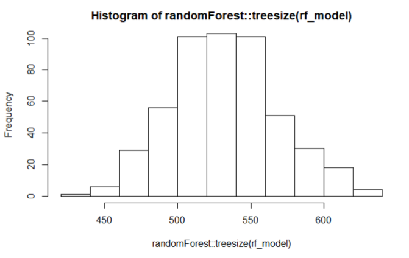

## 随机森林分类模型

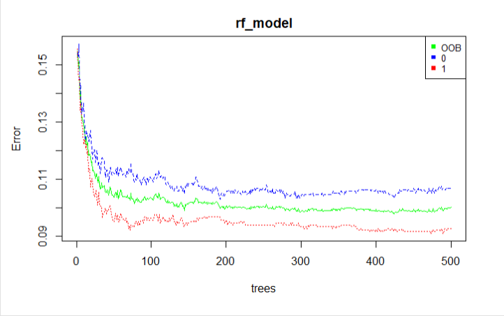

## 随机森林分类模型

- plot函数、varImpPlot函数

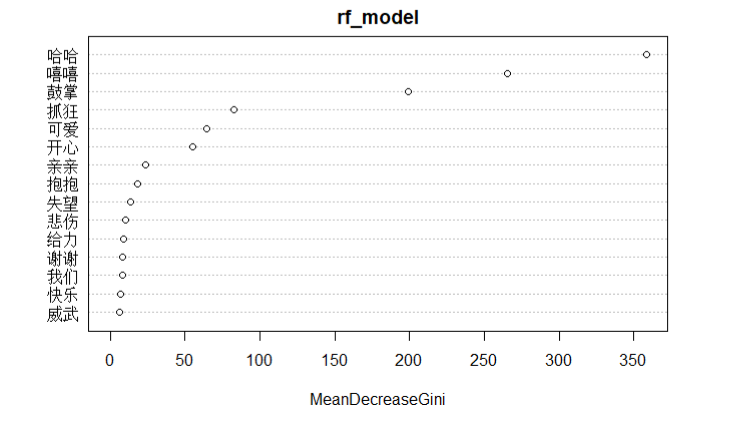

## 随机森林分类模型

- 预测
- 绘制roc曲线
- 计算测试集的精准率、召回率以及F值

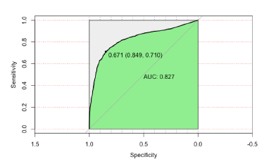

## svm分类模型

- r语言机器学习核心包
- 针对文本情感分类问题的主要参数“kernel”
- “radial”和“polynomial”
- 哪个效果好就用哪个

```
svm_model <- e1071::svm(y~.,data=train_final_df,kernel='radial', probability=TRUE)
```

## svm分类模型

- 通过summary及时了解模型情况

```
summary(svm_model)
```

- 训练集和测试集的预测

```
#用predict函数预测训练集
pre_train3 <-
predict(svm_model, train_final_df[1:(ncol(train_final_df) - 1)])

#预测测试集
pre_test3 <-
predict(svm_model, test_final_df[1:(ncol(test_final_df) - 1)])

#预测概率
prob_test3 <-
predict(svm_model, test_final_df[1:(ncol(test_final_df) - 1)], probability = TRUE)
prob_test3_2 <- attr(prob_test3, "probabilities")[,'1']
```

## svm分类模型

- 混淆矩阵1

| 3271 | 808 |
| --- | --- |
| 202 | 2719 |

- 混淆矩阵2

| 3278 | 1333 |
| --- | --- |
| 195 | 2194 |

## svm分类模型

通过混淆矩阵计算出

- svm模型1：正向情感的精准率为72.9%，召回率为82.8%，最终的F值为77.6%
- svm模型1：负向情感的精确率为80.0%，召回率为68.3%，F值为73.4%
- svm模型2：正向情感的精准率只有59.4%，召回率为80.0%，最终的F值为68%
- svm模型2：负向情感的精确率、召回率、F值均偏低

再一次表明svm算法模型2效果不如模型1。

## svm分类模型

分类效果可视化展示对比

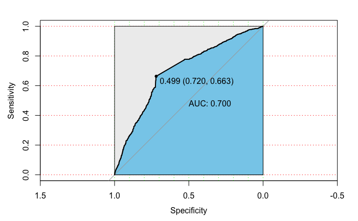

## svm分类模型

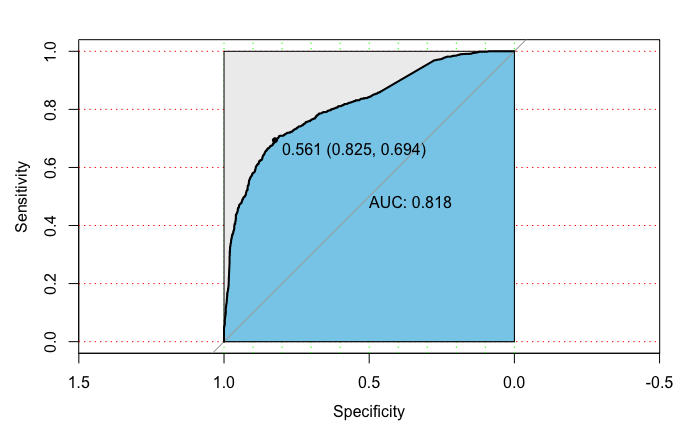

## svm分类模型

通过建立svm模型，也能得出这样的结论： 高斯核函数（radial）是一个典型的局部性核函数，而多项式核函数（polynomial）则是一个典型的全局性核函数。局部性核函数仅仅在测试点附近小领域内对数据点有影响，其学习能力强、泛化性能较弱；而全局性核函数则相对来说泛化性能较强、学习能力较弱，通过以上对两种svm模型的比较，也反映出了核函数的这种属性。

## xgb分类模型

- 进行模型训练
- 以树深为2，目标函数为二分类的逻辑回归
- 返回预测的概率，预测500次
- xgb对列有严格要求
- 要把列名排成一致的

## xgb分类模型

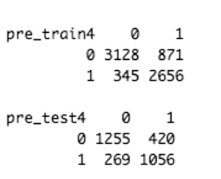

- 训练集的准确率83%，测试集77%
- label0的精准率达78.22%
- 召回率高达90.07%
- 最终的F值达83.73%

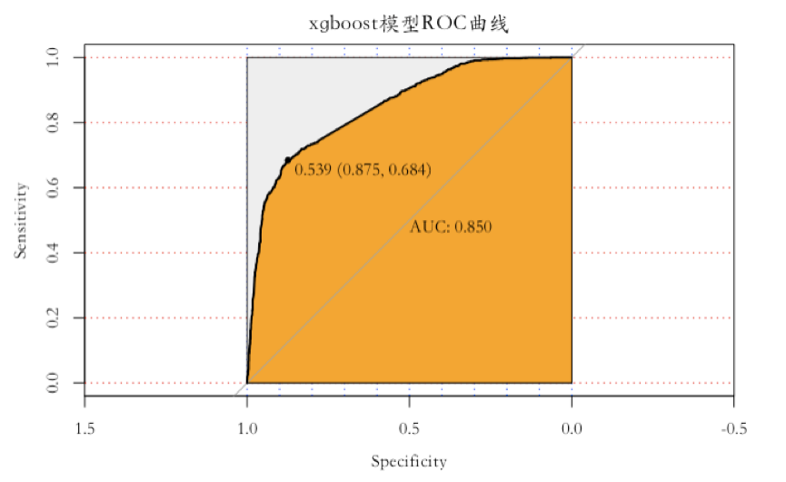

- 模型的AUC高达0.850
- 区分数据集正负例的效果很好
- xgb负向效果同样不错

## xgb分类模型

- 进行调参寻找最优模型
- 利用循环，对树的深度、迭代次数以及eta

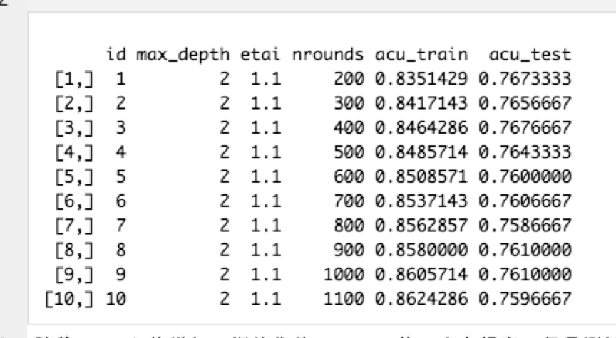

## 朴素贝叶斯分类模型

- 首先加载朴素贝叶斯所在包e1071，导入训练集和测试集

```
require(e1071)

  Train <- read.csv(file.choose())

  Test <- read.csv(file.choose())
```

- 返回对训练集的变量级别属性的值

```
  levels(Train$Item_Fat_Content)
```

## 朴素贝叶斯分类模型

- 建立朴素贝叶斯模型

```
model <- naiveBayes(Item_Fat_Content~., data = Train)
class(model)
```

- 预测模型

```
  pred <- predict(model,Test)
```

- 建立稀疏矩阵

```
  table(pred)
```

## 分析与总结

## 针对分类模型

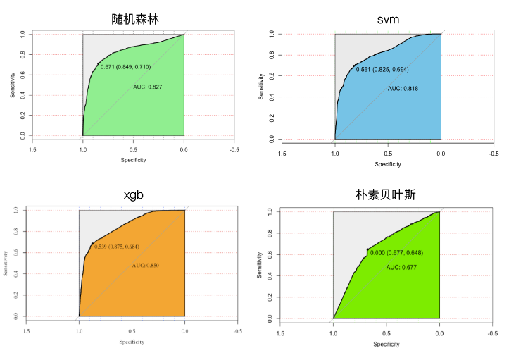

## 针对分类模型

综上所述：随机森林以及xgb相比于支持向量机和朴素贝叶斯模型在处理微博情感分类问题上更具有优势。使用SVM、xgb以及随机森林的微博文本分类准确率都较高, 朴素贝叶斯的准确率最低。

## 针对现实意义

- 通过网友微博的评论，可以通过分类算法判断改网友的情绪是正向还是负向。经过这样的自动处理，可以简单的判别出网友针对某一件事情的情感，例如：对当下华为事件的态度是**积极还是消极**、对明星某些行为是认可的还是反对的；
- 通过选取最优的分类模型，对网友的微博评论进行情感标注，一方面可以为广大机器学习爱好者提供带有标注的数据集，另一方方面可以扩充语料库；
- 上述的文本数据预处理以及分类算法，不仅在适用于微博评论的情感分析，它同样适用于电商评价以及电影的评价的情感分析，具有**普适性**。例如：淘宝商家通过买家的评论来揣测消费者的喜好，以方便其进行个性化定制。